# Airfares analysis

Exploratory data analysis of airfares data

As part of an interview process, I was given a data set of airfares as they are observed over 2 months. In the code below you can see the work I did to clean the data and prepare it for meaningful analysis and observation.  
I’ve calculated the volatility of the airfares of each flight based on the average and the standard deviation, and added the information to the data set so it can be used in viewing the trends of the prices over time.

In the other link, I created a dashboard for visualizing the airfares prices. The user can choose the flight market (e.g. BOSRIC - Boston to Richmond), the departure date, and even select a specific flight number. In addition, he/she can filter by volatility level (low, mid or high) or the trend of the prices (positive, negative). If there is more than one flight (e.g. the 5 flights from Boston to Richmond on May 5 that their price is going down) then the plot will show the average price over the observation time period.

Here’s the code for analyzing the data:

```python
# importing the libraries
import numpy as np
import pandas as pd
# Libraries to help with data visualization
import matplotlib.pyplot as plt
import seaborn as sns

# Command to tell Python to actually display the graphs
%matplotlib inline
```

```python
from google.colab import drive
drive.mount('/content/drive')
```

```python
path="/content/drive/MyDrive/airfares.csv"
data=pd.read_csv(path)
```

```python
data.info()
```

```
<class 'pandas.core.frame.DataFrame'>
RangeIndex: 1135211 entries, 0 to 1135210
Data columns (total 15 columns):
 #   Column            Non-Null Count    Dtype
---  ------            --------------    -----
 0   observation_date  1135211 non-null  object
 1   observation_time  1135211 non-null  object
 2   origin            1135211 non-null  object
 3   destination       1135211 non-null  object
 4   market            1135211 non-null  object
 5   carrier           1135211 non-null  object
 6   flight_number     1135211 non-null  int64
 7   departure_date    1135211 non-null  object
 8   departure_time    1135211 non-null  object
 9   fare_basis        1135211 non-null  object
 10  booking_class     1135211 non-null  object
 11  price_exc_tax     1129558 non-null  float64
 12  tax               1129558 non-null  float64
 13  price             1135211 non-null  float64
 14  currency          1135211 non-null  object
dtypes: float64(3), int64(1), object(11)
memory usage: 129.9+ MB
```

```python
data['departure_date'] = pd.to_datetime(data['departure_date'])
data['observation_date']  = pd.to_datetime(data['observation_date'])
```

```python
data.head()
```

[output not shown]

```python
data.groupby('market')['price'].describe()
```

| market | count | mean | std | min | 25% | 50% | 75% | max |
| --- | --- | --- | --- | --- | --- | --- | --- | --- |
| ABQJFK | 19354.0 | 172.383544 | 41.141688 | 113.98 | 145.98 | 160.98 | 178.98 | 525.15 |
| AUSMCO | 51526.0 | 116.349139 | 52.176950 | 38.30 | 78.29 | 103.30 | 141.62 | 568.30 |
| BOSLGA | 853613.0 | 111.809690 | 48.313285 | 48.30 | 82.30 | 97.30 | 112.30 | 598.30 |
| BOSRIC | 189877.0 | 121.245474 | 51.917115 | 65.30 | 82.30 | 98.30 | 148.30 | 590.69 |
| FLLPVD | 20841.0 | 143.380255 | 52.357114 | 83.30 | 113.98 | 124.98 | 153.05 | 580.97 |

```python
data_4_15 = data[data['observation_date'] == '2019-04-15'][data['market'] == 'AUSMCO']
data_4_15.describe()
```

[output not shown]

```python
grouped = data.groupby(['flight_number','carrier']).size().reset_index(name='Count')
```

[output not shown]

```python
flights_with_multiple_markets = grouped.groupby('flight_number').filter(lambda x: x['carrier'].nunique() > 1)
```

```python
print(flights_with_multiple_markets)
```

```
    flight_number carrier  Count
12            381      C7  10423
13            381      EM     26
45            732      C7   8479
46            732      OL   8230
```

```python
data['departure_year'] = data['departure_date'].dt.year
```

```python
data['departure_month'] =  data['departure_date'].dt.month
```

```python
data.head()
```

```python
c7_flights = data[(data['carrier'] == 'C7') & (data['departure_year'] == 2019) & (data['departure_month'] == 6)]
```

```python
c7_flights.groupby('market')['price'].describe()
```

| market | count | mean | std | min | 25% | 50% | 75% | max |
| --- | --- | --- | --- | --- | --- | --- | --- | --- |
| ABQJFK | 5160.0 | 179.456136 | 37.052482 | 113.98 | 160.98 | 169.80 | 190.50 | 387.98 |
| AUSMCO | 5160.0 | 144.688027 | 57.301812 | 58.30 | 103.30 | 138.05 | 163.30 | 568.30 |
| BOSLGA | 24248.0 | 90.789030 | 19.664549 | 58.30 | 82.30 | 82.30 | 95.30 | 251.30 |
| BOSRIC | 20290.0 | 119.489469 | 48.766870 | 72.30 | 82.30 | 98.30 | 148.30 | 315.30 |
| FLLPVD | 5160.0 | 132.219483 | 37.003207 | 88.98 | 113.98 | 124.98 | 143.98 | 396.98 |

```python
c7_flights.groupby(['market','flight_number','origin','destination'])['price'].mean()
```

```python
c7_flights.groupby(['market','flight_number','origin','destination'])['price'].std()
```

```python
data['days_remain'] = (data['departure_date'] - data['observation_date']).dt.days
```

```python
data.groupby('booking_class')['price'].count()
```

```python
grouped_data = data.groupby(['carrier','market','flight_number','origin','destination','departure_date','booking_class'])['price'].std()
```

```python
grouped_data = grouped_data.reset_index()
```

```python
grouped_data.to_csv('/content/drive/MyDrive/airfares_std.csv',index=False)
```

```python
top_3 = grouped_data.nlargest(3, 'price')
print(top_3)
```

```
      carrier  market  flight_number origin destination departure_date  \
27885      EM  BOSLGA           6031    BOS         LGA     2019-05-23
22893      EM  BOSLGA           5870    BOS         LGA     2019-07-05
16919      EM  BOSLGA            485    BOS         LGA     2019-05-17

      booking_class      price

27885 E 74.558627
22893 E 69.613412
16919 E 66.972631
```

```python
flight_6031 = data[(data['flight_number'] == 6031) & (data['booking_class'] == 'E') & (data['departure_date'] == '2019-05-23')]
flight_5870 = data[(data['flight_number'] == 5870) & (data['booking_class'] == 'E') & (data['departure_date'] == '2019-07-05')]
flight_485 = data[(data['flight_number'] == 485) & (data['booking_class'] == 'E') & (data['departure_date'] == '2019-05-17')]
```

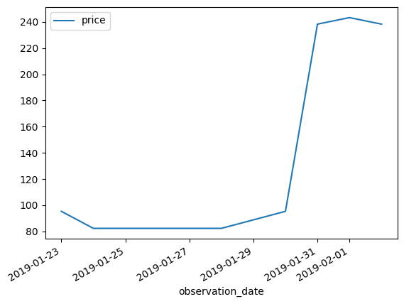

```python
# prompt: plot 'price' over 'observation_date'

flight_6031.plot(x='observation_date', y='price', kind='line')
```